# HW2_IE360

# LINEAR REGRESSION MODELS

## MODEL1

```r
fitted_model1<- lm(Unleaded.Gasoline.Sale..UGS.~ . -Quarter,data=hw2_data[1:28,] )
summary(fitted_model1)
```

```
##
## Call:
## lm(formula = Unleaded.Gasoline.Sale..UGS. ~ . - Quarter, data = hw2_data[1:28,
##     ])
##
## Residuals:
##    Min     1Q Median     3Q    Max
## -38364  -9454   -409   7421  33438
##
## Coefficients:
##                                         Estimate Std. Error t value Pr(>|t|)
## (Intercept)                            4.986e+06  2.057e+06   2.424   0.0416 *
## RNUV                                   3.504e+06  3.001e+06   1.168   0.2766
## X..LPG.Vehicles..NLPG.                -5.564e-01  2.999e-01  -1.855   0.1007
## Price.of.Unleaded.Gasoline..PU.        8.635e+02  1.604e+03   0.538   0.6049
## Price.of.Diesel.Gasoline..PG.         -2.634e+03  2.381e+03  -1.106   0.3008
## X..Unleaded.Gasoline.Vehicles..NUGV.  -1.521e+00  8.887e-01  -1.712   0.1253
## X..of.Diesel.Gasoline.Vehicles..NDGV.  1.718e+04  9.680e+03   1.775   0.1139
## GNP.Agriculture                       -4.690e-02  6.735e-02  -0.696   0.5059
## GNP.Commerce                           1.273e-01  1.153e-01   1.104   0.3016
## GNP.Total                             -1.510e-02  2.391e-02  -0.631   0.5454
## trend                                  2.338e+04  2.579e+04   0.907   0.3911
## quartes_info2                          3.018e+04  1.048e+05   0.288   0.7807
## quartes_info3                          4.411e+05  4.018e+05   1.098   0.3042
## quartes_info4                          1.900e+05  1.179e+05   1.611   0.1458
## lagged_values_lag1                    -5.164e-01  3.120e-01  -1.655   0.1364
## lagged_values_lag4                    -8.342e-02  2.660e-01  -0.314   0.7618
## ---
## Signif. codes:  0 '***' 0.001 '**' 0.01 '*' 0.05 '.' 0.1 ' ' 1
##
## Residual standard error: 29960 on 8 degrees of freedom
##   (4 observations deleted due to missingness)
## Multiple R-squared:  0.9796, Adjusted R-squared:  0.9414
## F-statistic: 25.63 on 15 and 8 DF,  p-value: 4.113e-05
```

```r
#checkresiduals(fitted_model1)
```

## Model 1 Comments

It is important to note, Quarter should not be added to model, so first think to do is subtracting it from the data. Since we are doing backward selection, all other variables are used. While making addition or subtraction, we will focus on the variables’ significance,adjusted R^2 and Residual Standart Error values. At the beginning one of variables which have high Pr(>|t|) values will be eliminated.

## MODEL2

```r
fitted_model2<- lm(Unleaded.Gasoline.Sale..UGS. ~. -Quarter-GNP.Agriculture ,data=hw2_data[1:28,] )
summary(fitted_model2)
```

```
##
## Call:
## lm(formula = Unleaded.Gasoline.Sale..UGS. ~ . - Quarter - GNP.Agriculture,
##     data = hw2_data[1:28, ])
##
## Residuals:
##    Min     1Q Median     3Q    Max
## -37742  -7301   1046   6087  39182
##
## Coefficients:
##                                         Estimate Std. Error t value Pr(>|t|)
## (Intercept)                            4.408e+06  1.828e+06   2.412   0.0391 *
## RNUV                                   2.729e+06  2.707e+06   1.008   0.3396
## X..LPG.Vehicles..NLPG.                -4.353e-01  2.373e-01  -1.834   0.0998 .
## Price.of.Unleaded.Gasoline..PU.        4.783e+02  1.461e+03   0.327   0.7509
## Price.of.Diesel.Gasoline..PG.         -1.864e+03  2.047e+03  -0.910   0.3864
## X..Unleaded.Gasoline.Vehicles..NUGV.  -1.276e+00  7.923e-01  -1.611   0.1417
## X..of.Diesel.Gasoline.Vehicles..NDGV.  1.474e+04  8.764e+03   1.682   0.1268
## GNP.Commerce                           1.329e-01  1.117e-01   1.190   0.2646
## GNP.Total                             -1.999e-02  2.220e-02  -0.900   0.3914
## trend                                  1.385e+04  2.123e+04   0.653   0.5303
## quartes_info2                          6.520e+03  9.625e+04   0.068   0.9475
## quartes_info3                          2.127e+05  2.252e+05   0.944   0.3697
## quartes_info4                          1.679e+05  1.103e+05   1.523   0.1621
## lagged_values_lag1                    -6.075e-01  2.751e-01  -2.208   0.0546 .
## lagged_values_lag4                    -4.718e-02  2.532e-01  -0.186   0.8564
## ---
## Signif. codes:  0 '***' 0.001 '**' 0.01 '*' 0.05 '.' 0.1 ' ' 1
##
## Residual standard error: 29090 on 9 degrees of freedom
##   (4 observations deleted due to missingness)
## Multiple R-squared:  0.9784, Adjusted R-squared:  0.9447
## F-statistic: 29.09 on 14 and 9 DF,  p-value: 9.117e-06
```

```r
#checkresiduals(fitted_model2)
```

## MODEL3

```r
fitted_model3<- lm(Unleaded.Gasoline.Sale..UGS.~. -Quarter-GNP.Agriculture-Price.of.Diesel.Gasoline..PG. ,data=hw2_data[1:28,] )
summary(fitted_model3)
```

```
##
## Call:
## lm(formula = Unleaded.Gasoline.Sale..UGS. ~ . - Quarter - GNP.Agriculture -
##     Price.of.Diesel.Gasoline..PG., data = hw2_data[1:28, ])
##
## Residuals:
##    Min     1Q Median     3Q    Max
## -44943  -8950   -644  11340  36871
##
## Coefficients:
##                                         Estimate Std. Error t value Pr(>|t|)
## (Intercept)                            4.728e+06  1.779e+06   2.658  0.02398 *
## RNUV                                   2.864e+06  2.679e+06   1.069  0.31014
## X..LPG.Vehicles..NLPG.                -3.352e-01  2.085e-01  -1.608  0.13895
## Price.of.Unleaded.Gasoline..PU.       -8.327e+02  2.467e+02  -3.375  0.00706 **
## X..Unleaded.Gasoline.Vehicles..NUGV.  -1.459e+00  7.600e-01  -1.919  0.08393 .
## X..of.Diesel.Gasoline.Vehicles..NDGV.  1.714e+04  8.288e+03   2.068  0.06553 .
## GNP.Commerce                           6.124e-02  7.859e-02   0.779  0.45388
## GNP.Total                             -1.062e-02  1.950e-02  -0.545  0.59801
## trend                                  8.392e+03  2.019e+04   0.416  0.68636
## quartes_info2                          5.926e+04  7.619e+04   0.778  0.45469
## quartes_info3                          3.074e+05  1.980e+05   1.552  0.15168
## quartes_info4                          2.144e+05  9.690e+04   2.212  0.05138 .
## lagged_values_lag1                    -6.290e-01  2.717e-01  -2.315  0.04313 *
## lagged_values_lag4                    -1.234e-01  2.369e-01  -0.521  0.61379
## ---
## Signif. codes:  0 '***' 0.001 '**' 0.01 '*' 0.05 '.' 0.1 ' ' 1
##
## Residual standard error: 28840 on 10 degrees of freedom
##   (4 observations deleted due to missingness)
## Multiple R-squared:  0.9764, Adjusted R-squared:  0.9457
## F-statistic: 31.81 on 13 and 10 DF,  p-value: 2.267e-06
```

```r
#checkresiduals(fitted_model3)
```

## Model 3 Comments

At model 3, we subtracted Price.of.Diesel.Gasoline..PG. since it has high correlation with Price.of.Unleaded.Gasoline..PU. The main reason for not subtracting PU variable is PU variable seems to important variable because of its definition.

## MODEL4

```r
fitted_model4<- lm(Unleaded.Gasoline.Sale..UGS.~. -Quarter-GNP.Agriculture-Price.of.Diesel.Gasoline..PG.- GNP.Total  ,data=hw2_data[1:28,] )
summary(fitted_model4)
```

```
##
## Call:
## lm(formula = Unleaded.Gasoline.Sale..UGS. ~ . - Quarter - GNP.Agriculture -
##     Price.of.Diesel.Gasoline..PG. - GNP.Total, data = hw2_data[1:28,
##     ])
##
## Residuals:
##    Min     1Q Median     3Q    Max
## -42531 -10266   -377  15178  36770
##
## Coefficients:
##                                         Estimate Std. Error t value Pr(>|t|)
## (Intercept)                            4.715e+06  1.721e+06   2.740  0.01923 *
## RNUV                                   3.314e+06  2.466e+06   1.344  0.20610
## X..LPG.Vehicles..NLPG.                -3.160e-01  1.988e-01  -1.590  0.14022
## Price.of.Unleaded.Gasoline..PU.       -8.738e+02  2.273e+02  -3.845  0.00272 **
## X..Unleaded.Gasoline.Vehicles..NUGV.  -1.494e+00  7.325e-01  -2.040  0.06609 .
## X..of.Diesel.Gasoline.Vehicles..NDGV.  1.788e+04  7.909e+03   2.261  0.04505 *
## GNP.Commerce                           3.601e-02  6.141e-02   0.586  0.56948
## trend                                  4.311e+03  1.813e+04   0.238  0.81644
## quartes_info2                          5.131e+04  7.235e+04   0.709  0.49298
## quartes_info3                          2.620e+05  1.738e+05   1.507  0.15990
## quartes_info4                          1.953e+05  8.741e+04   2.234  0.04719 *
## lagged_values_lag1                    -6.838e-01  2.442e-01  -2.800  0.01727 *
## lagged_values_lag4                    -1.511e-01  2.239e-01  -0.675  0.51369
## ---
## Signif. codes:  0 '***' 0.001 '**' 0.01 '*' 0.05 '.' 0.1 ' ' 1
##
## Residual standard error: 27910 on 11 degrees of freedom
##   (4 observations deleted due to missingness)
## Multiple R-squared:  0.9757, Adjusted R-squared:  0.9492
## F-statistic: 36.79 on 12 and 11 DF,  p-value: 4.112e-07
```

```r
#checkresiduals(fitted_model4)
```

## Model 4 Comments

As expected, PU variable become highly significant and our model improved. GNP Total is subtracted from the model due to the fact that its significance was low compared to other variable. With these changes, the number of significant variables is increased.

## MODEL5

```r
fitted_model5<- lm(Unleaded.Gasoline.Sale..UGS.~. -Quarter-GNP.Agriculture-Price.of.Diesel.Gasoline..PG.- GNP.Total -GNP.Commerce  ,data=hw2_data[1:28,] )
summary(fitted_model5)
```

```
##
## Call:
## lm(formula = Unleaded.Gasoline.Sale..UGS. ~ . - Quarter - GNP.Agriculture -
##     Price.of.Diesel.Gasoline..PG. - GNP.Total - GNP.Commerce,
##     data = hw2_data[1:28, ])
##
## Residuals:
##    Min     1Q Median     3Q    Max
## -45242  -9314  -1075  15477  34355
##
## Coefficients:
##                                         Estimate Std. Error t value Pr(>|t|)
## (Intercept)                            5.294e+06  1.370e+06   3.864 0.002254
## RNUV                                   3.393e+06  2.394e+06   1.417 0.181817
## X..LPG.Vehicles..NLPG.                -3.504e-01  1.847e-01  -1.897 0.082173
## Price.of.Unleaded.Gasoline..PU.       -8.347e+02  2.112e+02  -3.952 0.001922
## X..Unleaded.Gasoline.Vehicles..NUGV.  -1.751e+00  5.708e-01  -3.068 0.009755
## X..of.Diesel.Gasoline.Vehicles..NDGV.  2.062e+04  6.205e+03   3.323 0.006077
## trend                                  1.093e+04  1.379e+04   0.792 0.443483
## quartes_info2                          8.888e+04  3.264e+04   2.723 0.018506
## quartes_info3                          3.568e+05  6.210e+04   5.746 9.22e-05
## quartes_info4                          2.369e+05  4.951e+04   4.786 0.000444
## lagged_values_lag1                    -6.343e-01  2.228e-01  -2.847 0.014704
## lagged_values_lag4                    -1.905e-01  2.076e-01  -0.918 0.376879
##
## (Intercept)                           **
## RNUV
## X..LPG.Vehicles..NLPG.                .
## Price.of.Unleaded.Gasoline..PU.       **
## X..Unleaded.Gasoline.Vehicles..NUGV.  **
## X..of.Diesel.Gasoline.Vehicles..NDGV. **
## trend
## quartes_info2                         *
## quartes_info3                         ***
## quartes_info4                         ***
## lagged_values_lag1                    *
## lagged_values_lag4
## ---
## Signif. codes:  0 '***' 0.001 '**' 0.01 '*' 0.05 '.' 0.1 ' ' 1
##
## Residual standard error: 27130 on 12 degrees of freedom
##   (4 observations deleted due to missingness)
## Multiple R-squared:  0.9749, Adjusted R-squared:  0.9519
## F-statistic: 42.42 on 11 and 12 DF,  p-value: 7.113e-08
```

```r
#checkresiduals(fitted_model5)
```

## Model 5 Comments

Model 5 performs better than the previous one. The change we have made is subtracting GNP.Commerce variable. GNP.Commerce is subtracted from the model due to the fact that its significance was low compared to other variable just like previous step.

## MODEL6

```r
fitted_model6<- lm(Unleaded.Gasoline.Sale..UGS.~. -Quarter-GNP.Agriculture-Price.of.Diesel.Gasoline..PG.- GNP.Total -GNP.Commerce -RNUV,data=hw2_data[1:28,] )
summary(fitted_model6)
```

```
##
## Call:
## lm(formula = Unleaded.Gasoline.Sale..UGS. ~ . - Quarter - GNP.Agriculture -
##     Price.of.Diesel.Gasoline..PG. - GNP.Total - GNP.Commerce -
##     RNUV, data = hw2_data[1:28, ])
##
## Residuals:
##    Min     1Q Median     3Q    Max
## -41723 -14224  -3069  14151  43104
##
## Coefficients:
##                                         Estimate Std. Error t value Pr(>|t|)
## (Intercept)                            4.503e+06  1.299e+06   3.466 0.004175
## X..LPG.Vehicles..NLPG.                -2.787e-01  1.844e-01  -1.511 0.154629
## Price.of.Unleaded.Gasoline..PU.       -7.112e+02  1.997e+02  -3.561 0.003485
## X..Unleaded.Gasoline.Vehicles..NUGV.  -1.530e+00  5.700e-01  -2.685 0.018738
## X..of.Diesel.Gasoline.Vehicles..NDGV.  1.832e+04  6.217e+03   2.946 0.011350
## trend                                  9.364e+03  1.427e+04   0.656 0.523279
## quartes_info2                          9.454e+04  3.363e+04   2.811 0.014711
## quartes_info3                          3.283e+05  6.097e+04   5.384 0.000125
## quartes_info4                          2.203e+05  4.993e+04   4.412 0.000702
## lagged_values_lag1                    -5.168e-01  2.147e-01  -2.407 0.031645
## lagged_values_lag4                    -8.319e-02  2.007e-01  -0.415 0.685260
##
## (Intercept)                           **
## X..LPG.Vehicles..NLPG.
## Price.of.Unleaded.Gasoline..PU.       **
## X..Unleaded.Gasoline.Vehicles..NUGV.  *
## X..of.Diesel.Gasoline.Vehicles..NDGV. *
## trend
## quartes_info2                         *
## quartes_info3                         ***
## quartes_info4                         ***
## lagged_values_lag1                    *
## lagged_values_lag4
## ---
## Signif. codes:  0 '***' 0.001 '**' 0.01 '*' 0.05 '.' 0.1 ' ' 1
##
## Residual standard error: 28170 on 13 degrees of freedom
##   (4 observations deleted due to missingness)
## Multiple R-squared:  0.9707, Adjusted R-squared:  0.9482
## F-statistic: 43.12 on 10 and 13 DF,  p-value: 2.572e-08
```

```r
#checkresiduals(fitted_model6)
```

## Mode6 Comments

RNUV is subtracted and the model is not improved as can be seen from the adjusted R^2 and residual standart error.

## MODEL7

```r
fitted_model7<- lm(Unleaded.Gasoline.Sale..UGS.~. -Quarter-GNP.Agriculture-Price.of.Diesel.Gasoline..PG.- GNP.Total -GNP.Commerce -RNUV-lagged_values_lag4 ,data=hw2_data[1:28,] )
summary(fitted_model7)
```

```
##
## Call:
## lm(formula = Unleaded.Gasoline.Sale..UGS. ~ . - Quarter - GNP.Agriculture -
##     Price.of.Diesel.Gasoline..PG. - GNP.Total - GNP.Commerce -
##     RNUV - lagged_values_lag4, data = hw2_data[1:28, ])
##
## Residuals:
##    Min     1Q Median     3Q    Max
## -43432 -14735  -2217  14303  42518
##
## Coefficients:
##                                         Estimate Std. Error t value Pr(>|t|)
## (Intercept)                            4.452e+06  1.254e+06   3.549  0.00321
## X..LPG.Vehicles..NLPG.                -2.962e-01  1.742e-01  -1.700  0.11117
## Price.of.Unleaded.Gasoline..PU.       -7.284e+02  1.895e+02  -3.844  0.00179
## X..Unleaded.Gasoline.Vehicles..NUGV.  -1.521e+00  5.525e-01  -2.753  0.01556
## X..of.Diesel.Gasoline.Vehicles..NDGV.  1.801e+04  5.988e+03   3.008  0.00940
## trend                                  1.183e+04  1.258e+04   0.941  0.36282
## quartes_info2                          8.564e+04  2.509e+04   3.413  0.00420
## quartes_info3                          3.043e+05  1.855e+04  16.401 1.55e-10
## quartes_info4                          2.111e+05  4.340e+04   4.864  0.00025
## lagged_values_lag1                    -5.061e-01  2.067e-01  -2.448  0.02814
##
## (Intercept)                           **
## X..LPG.Vehicles..NLPG.
## Price.of.Unleaded.Gasoline..PU.       **
## X..Unleaded.Gasoline.Vehicles..NUGV.  *
## X..of.Diesel.Gasoline.Vehicles..NDGV. **
## trend
## quartes_info2                         **
## quartes_info3                         ***
## quartes_info4                         ***
## lagged_values_lag1                    *
## ---
## Signif. codes:  0 '***' 0.001 '**' 0.01 '*' 0.05 '.' 0.1 ' ' 1
##
## Residual standard error: 27320 on 14 degrees of freedom
##   (4 observations deleted due to missingness)
## Multiple R-squared:  0.9703, Adjusted R-squared:  0.9513
## F-statistic:  50.9 on 9 and 14 DF,  p-value: 3.735e-09
```

```r
#checkresiduals(fitted_model7)
```

## Model 7 Comments

Although Model 6 does not lead to improvement, we subtracted the lag4 value from the model to see lag 4 and RNUV effects together. However, Model 5 performs better. Therefore, our final model is not found yet.

## MODEL 8

```r
fitted_model8<- lm(Unleaded.Gasoline.Sale..UGS.~. -Quarter-GNP.Agriculture-Price.of.Diesel.Gasoline..PG.- GNP.Total -GNP.Commerce-lagged_values_lag4 -X..LPG.Vehicles..NLPG. ,data=hw2_data[1:28,] )
summary(fitted_model8)
```

```
##
## Call:
## lm(formula = Unleaded.Gasoline.Sale..UGS. ~ . - Quarter - GNP.Agriculture -
##     Price.of.Diesel.Gasoline..PG. - GNP.Total - GNP.Commerce -
##     lagged_values_lag4 - X..LPG.Vehicles..NLPG., data = hw2_data[1:28,
##     ])
##
## Residuals:
##    Min     1Q Median     3Q    Max
## -43818 -14526  -6735  15116  42298
##
## Coefficients:
##                                         Estimate Std. Error t value Pr(>|t|)
## (Intercept)                            2.825e+06  8.463e+05   3.338 0.004875
## RNUV                                   1.089e+06  2.303e+06   0.473 0.643743
## Price.of.Unleaded.Gasoline..PU.       -6.331e+02  2.022e+02  -3.131 0.007360
## X..Unleaded.Gasoline.Vehicles..NUGV.  -7.284e-01  3.366e-01  -2.164 0.048234
## X..of.Diesel.Gasoline.Vehicles..NDGV.  9.189e+03  3.571e+03   2.573 0.022094
## trend                                 -8.797e+03  4.806e+03  -1.830 0.088557
## quartes_info2                          8.876e+04  2.866e+04   3.097 0.007883
## quartes_info3                          3.043e+05  2.026e+04  15.018 5.01e-10
## quartes_info4                          1.944e+05  4.608e+04   4.217 0.000861
## lagged_values_lag1                    -4.962e-01  2.323e-01  -2.136 0.050801
##
## (Intercept)                           **
## RNUV
## Price.of.Unleaded.Gasoline..PU.       **
## X..Unleaded.Gasoline.Vehicles..NUGV.  *
## X..of.Diesel.Gasoline.Vehicles..NDGV. *
## trend                                 .
## quartes_info2                         **
## quartes_info3                         ***
## quartes_info4                         ***
## lagged_values_lag1                    .
## ---
## Signif. codes:  0 '***' 0.001 '**' 0.01 '*' 0.05 '.' 0.1 ' ' 1
##
## Residual standard error: 29770 on 14 degrees of freedom
##   (4 observations deleted due to missingness)
## Multiple R-squared:  0.9648, Adjusted R-squared:  0.9421
## F-statistic: 42.61 on 9 and 14 DF,  p-value: 1.223e-08
```

```r
#checkresiduals(fitted_model8)
```

## Model 8 Comments

X..LPG.Vehicles..NLPG. variable is subtracted. Although it did not lead to improvement, X..LPG.Vehicles..NLPG. is not relevant with our UGS sales therefore, it will not be added back.

## MODEL 9

```r
hw2_data$RNUV_lagg1<- NA
for(i in 1:28){
  hw2_data$RNUV_lagg1[i+1] = hw2_data$RNUV[i]
}

fitted_model9<- lm(Unleaded.Gasoline.Sale..UGS.~. -Quarter-GNP.Agriculture-Price.of.Diesel.Gasoline..PG.- GNP.Total -GNP.Commerce-lagged_values_lag4 -X..LPG.Vehicles..NLPG. -RNUV ,data=hw2_data[1:28,] )
summary(fitted_model9)
```

```
##
## Call:
## lm(formula = Unleaded.Gasoline.Sale..UGS. ~ . - Quarter - GNP.Agriculture -
##     Price.of.Diesel.Gasoline..PG. - GNP.Total - GNP.Commerce -
##     lagged_values_lag4 - X..LPG.Vehicles..NLPG. - RNUV, data = hw2_data[1:28,
##     ])
##
## Residuals:
##    Min     1Q Median     3Q    Max
## -42271 -12572  -4662  12206  39758
##
## Coefficients:
##                                         Estimate Std. Error t value Pr(>|t|)
## (Intercept)                            2.748e+06  8.411e+05   3.267  0.00562
## Price.of.Unleaded.Gasoline..PU.       -5.941e+02  1.906e+02  -3.118  0.00756
## X..Unleaded.Gasoline.Vehicles..NUGV.  -7.633e-01  3.427e-01  -2.228  0.04283
## X..of.Diesel.Gasoline.Vehicles..NDGV.  9.904e+03  3.769e+03   2.628  0.01988
## trend                                 -8.225e+03  4.695e+03  -1.752  0.10168
## quartes_info2                          8.842e+04  3.055e+04   2.894  0.01177
## quartes_info3                          3.013e+05  2.279e+04  13.224 2.66e-09
## quartes_info4                          1.905e+05  4.760e+04   4.003  0.00131
## lagged_values_lag1                    -4.631e-01  2.249e-01  -2.059  0.05862
## RNUV_lagg1                            -7.482e+05  2.126e+06  -0.352  0.73009
##
## (Intercept)                           **
## Price.of.Unleaded.Gasoline..PU.       **
## X..Unleaded.Gasoline.Vehicles..NUGV.  *
## X..of.Diesel.Gasoline.Vehicles..NDGV. *
## trend
## quartes_info2                         *
## quartes_info3                         ***
## quartes_info4                         **
## lagged_values_lag1                    .
## RNUV_lagg1
## ---
## Signif. codes:  0 '***' 0.001 '**' 0.01 '*' 0.05 '.' 0.1 ' ' 1
##
## Residual standard error: 29880 on 14 degrees of freedom
##   (4 observations deleted due to missingness)
## Multiple R-squared:  0.9645, Adjusted R-squared:  0.9417
## F-statistic:  42.3 on 9 and 14 DF,  p-value: 1.283e-08
```

```r
#checkresiduals(fitted_model9)
```

## MODEL 10

```r
fitted_model10<- lm(Unleaded.Gasoline.Sale..UGS.~. -Quarter-GNP.Agriculture-Price.of.Diesel.Gasoline..PG.- GNP.Total -GNP.Commerce-lagged_values_lag4 -X..LPG.Vehicles..NLPG. -RNUV_lagg1 -X..Unleaded.Gasoline.Vehicles..NUGV. ,data=hw2_data[1:28,] )
summary(fitted_model10)
```

```
##
## Call:
## lm(formula = Unleaded.Gasoline.Sale..UGS. ~ . - Quarter - GNP.Agriculture -
##     Price.of.Diesel.Gasoline..PG. - GNP.Total - GNP.Commerce -
##     lagged_values_lag4 - X..LPG.Vehicles..NLPG. - RNUV_lagg1 -
##     X..Unleaded.Gasoline.Vehicles..NUGV., data = hw2_data[1:28,
##     ])
##
## Residuals:
##    Min     1Q Median     3Q    Max
## -56009 -16518  -3525  18066  41931
##
## Coefficients:
##                                         Estimate Std. Error t value Pr(>|t|)
## (Intercept)                            1.147e+06  3.781e+05   3.034  0.00838
## RNUV                                   1.481e+06  2.563e+06   0.578  0.57178
## Price.of.Unleaded.Gasoline..PU.       -6.330e+02  2.256e+02  -2.805  0.01331
## X..of.Diesel.Gasoline.Vehicles..NDGV.  1.724e+03  1.031e+03   1.673  0.11505
## trend                                 -1.573e+04  3.999e+03  -3.933  0.00133
## quartes_info2                          1.074e+05  3.051e+04   3.522  0.00308
## quartes_info3                          2.933e+05  2.189e+04  13.398 9.45e-10
## quartes_info4                          1.426e+05  4.395e+04   3.244  0.00545
## lagged_values_lag1                    -2.808e-01  2.342e-01  -1.199  0.24916
##
## (Intercept)                           **
## RNUV
## Price.of.Unleaded.Gasoline..PU.       *
## X..of.Diesel.Gasoline.Vehicles..NDGV.
## trend                                 **
## quartes_info2                         **
## quartes_info3                         ***
## quartes_info4                         **
## lagged_values_lag1
## ---
## Signif. codes:  0 '***' 0.001 '**' 0.01 '*' 0.05 '.' 0.1 ' ' 1
##
## Residual standard error: 33230 on 15 degrees of freedom
##   (4 observations deleted due to missingness)
## Multiple R-squared:  0.953,  Adjusted R-squared:  0.9279
## F-statistic: 38.02 on 8 and 15 DF,  p-value: 1.367e-08
```

```r
#checkresiduals(fitted_model10)
```

### Model 10 Comments

Since lag1 value of RNUV and NDUV are somehow related because of their definition. X..Unleaded.Gasoline.Vehicles..NUGV. is removed and RUNV is added back. However, it did not performed well compared to previos one therefore X..Unleaded.Gasoline.Vehicles..NUGV. is decided to kept in the model.

## MODEL 11

```r
fitted_model11<- lm(Unleaded.Gasoline.Sale..UGS.~. -Quarter-GNP.Agriculture-Price.of.Diesel.Gasoline..PG.- GNP.Total -GNP.Commerce-lagged_values_lag4 -X..LPG.Vehicles..NLPG.- RNUV_lagg1 ,data=hw2_data[1:28,] )
summary(fitted_model11)
```

```
##
## Call:
## lm(formula = Unleaded.Gasoline.Sale..UGS. ~ . - Quarter - GNP.Agriculture -
##     Price.of.Diesel.Gasoline..PG. - GNP.Total - GNP.Commerce -
##     lagged_values_lag4 - X..LPG.Vehicles..NLPG. - RNUV_lagg1,
##     data = hw2_data[1:28, ])
##
## Residuals:
##    Min     1Q Median     3Q    Max
## -43818 -14526  -6735  15116  42298
##
## Coefficients:
##                                         Estimate Std. Error t value Pr(>|t|)
## (Intercept)                            2.825e+06  8.463e+05   3.338 0.004875
## RNUV                                   1.089e+06  2.303e+06   0.473 0.643743
## Price.of.Unleaded.Gasoline..PU.       -6.331e+02  2.022e+02  -3.131 0.007360
## X..Unleaded.Gasoline.Vehicles..NUGV.  -7.284e-01  3.366e-01  -2.164 0.048234
## X..of.Diesel.Gasoline.Vehicles..NDGV.  9.189e+03  3.571e+03   2.573 0.022094
## trend                                 -8.797e+03  4.806e+03  -1.830 0.088557
## quartes_info2                          8.876e+04  2.866e+04   3.097 0.007883
## quartes_info3                          3.043e+05  2.026e+04  15.018 5.01e-10
## quartes_info4                          1.944e+05  4.608e+04   4.217 0.000861
## lagged_values_lag1                    -4.962e-01  2.323e-01  -2.136 0.050801
##
## (Intercept)                           **
## RNUV
## Price.of.Unleaded.Gasoline..PU.       **
## X..Unleaded.Gasoline.Vehicles..NUGV.  *
## X..of.Diesel.Gasoline.Vehicles..NDGV. *
## trend                                 .
## quartes_info2                         **
## quartes_info3                         ***
## quartes_info4                         ***
## lagged_values_lag1                    .
## ---
## Signif. codes:  0 '***' 0.001 '**' 0.01 '*' 0.05 '.' 0.1 ' ' 1
##
## Residual standard error: 29770 on 14 degrees of freedom
##   (4 observations deleted due to missingness)
## Multiple R-squared:  0.9648, Adjusted R-squared:  0.9421
## F-statistic: 42.61 on 9 and 14 DF,  p-value: 1.223e-08
```

```r
#checkresiduals(fitted_model11)
```

### Model 11 Comments

RNUV and X..Unleaded.Gasoline.Vehicles..NUGV. are added back, next iteration will be done to this model.

# FINAL MODEL

```r
final_model12<- lm(Unleaded.Gasoline.Sale..UGS.~ +Price.of.Unleaded.Gasoline..PU. + X..Unleaded.Gasoline.Vehicles..NUGV. + X..of.Diesel.Gasoline.Vehicles..NDGV. + trend + quartes_info + lagged_values_lag1 ,data=hw2_data[1:28,] )
summary(final_model12)
```

```
##
## Call:
## lm(formula = Unleaded.Gasoline.Sale..UGS. ~ +Price.of.Unleaded.Gasoline..PU. +
##     X..Unleaded.Gasoline.Vehicles..NUGV. + X..of.Diesel.Gasoline.Vehicles..NDGV. +
##     trend + quartes_info + lagged_values_lag1, data = hw2_data[1:28,
##     ])
##
## Residuals:
##    Min     1Q Median     3Q    Max
## -44528 -10996  -4285  15377  39939
##
## Coefficients:
##                                         Estimate Std. Error t value Pr(>|t|)
## (Intercept)                            2.796e+06  6.050e+05   4.621 0.000212
## Price.of.Unleaded.Gasoline..PU.       -6.308e+02  1.628e+02  -3.876 0.001108
## X..Unleaded.Gasoline.Vehicles..NUGV.  -7.551e-01  2.011e-01  -3.755 0.001450
## X..of.Diesel.Gasoline.Vehicles..NDGV.  9.724e+03  2.033e+03   4.782 0.000149
## trend                                 -8.559e+03  3.562e+03  -2.403 0.027253
## quartes_info2                          9.041e+04  2.366e+04   3.821 0.001252
## quartes_info3                          3.099e+05  1.729e+04  17.924 6.33e-13
## quartes_info4                          1.985e+05  4.069e+04   4.878 0.000121
## lagged_values_lag1                    -4.865e-01  1.947e-01  -2.499 0.022362
##
## (Intercept)                           ***
## Price.of.Unleaded.Gasoline..PU.       **
## X..Unleaded.Gasoline.Vehicles..NUGV.  **
## X..of.Diesel.Gasoline.Vehicles..NDGV. ***
## trend                                 *
## quartes_info2                         **
## quartes_info3                         ***
## quartes_info4                         ***
## lagged_values_lag1                    *
## ---
## Signif. codes:  0 '***' 0.001 '**' 0.01 '*' 0.05 '.' 0.1 ' ' 1
##
## Residual standard error: 27090 on 18 degrees of freedom
##   (1 observation deleted due to missingness)
## Multiple R-squared:  0.9778, Adjusted R-squared:  0.9679
## F-statistic: 99.11 on 8 and 18 DF,  p-value: 2.71e-13
```

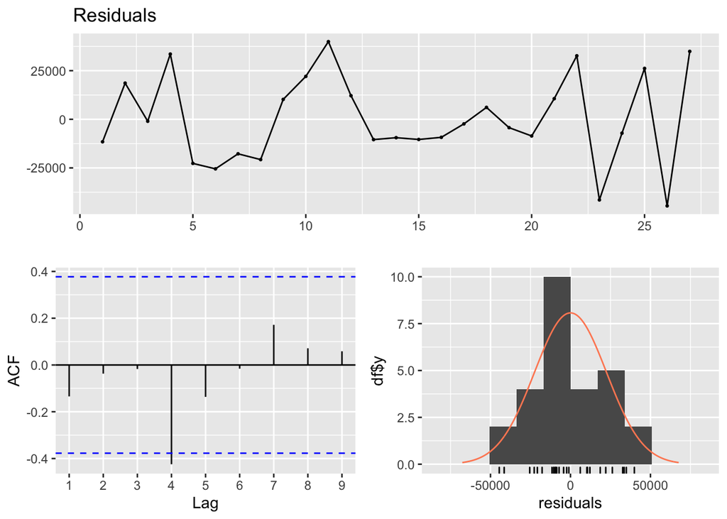

```
##
##  Breusch-Godfrey test for serial correlation of order up to 12
##
## data:  Residuals
## LM test = 20.476, df = 12, p-value = 0.05859
```

```r
checkresiduals(final_model12)
```

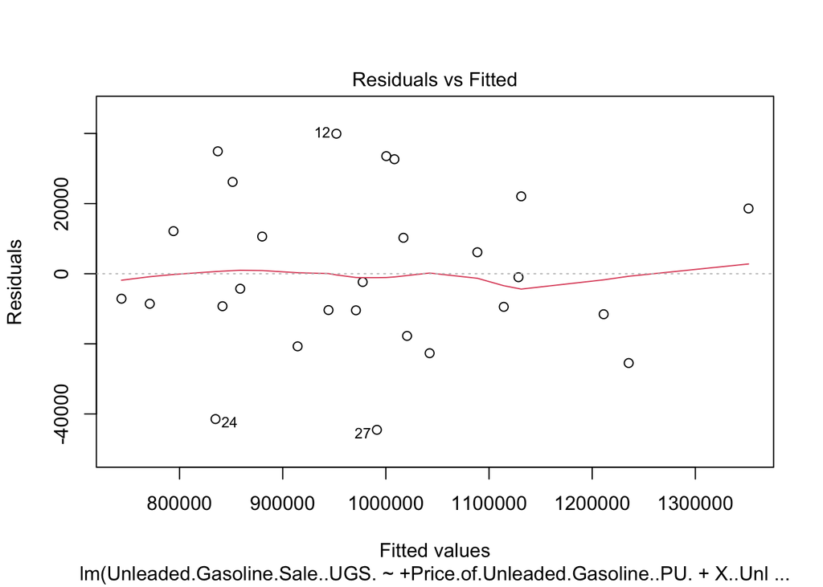

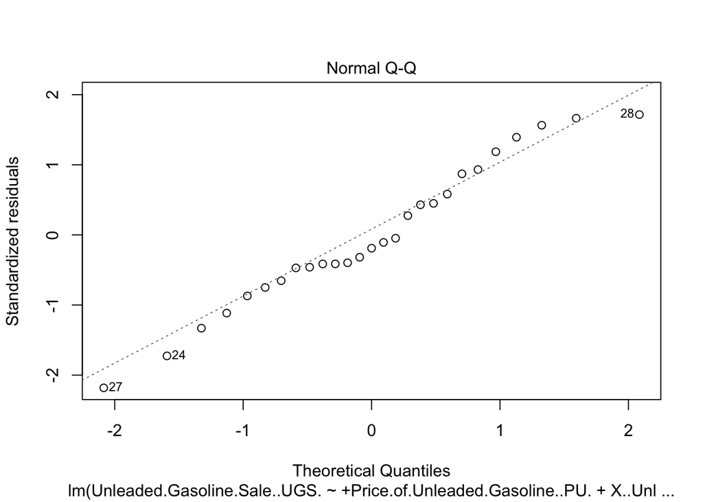

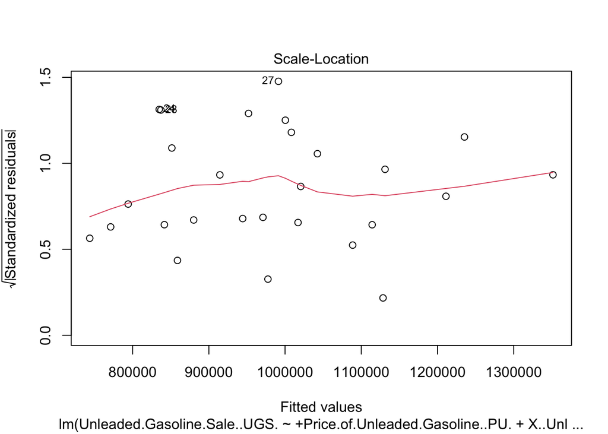

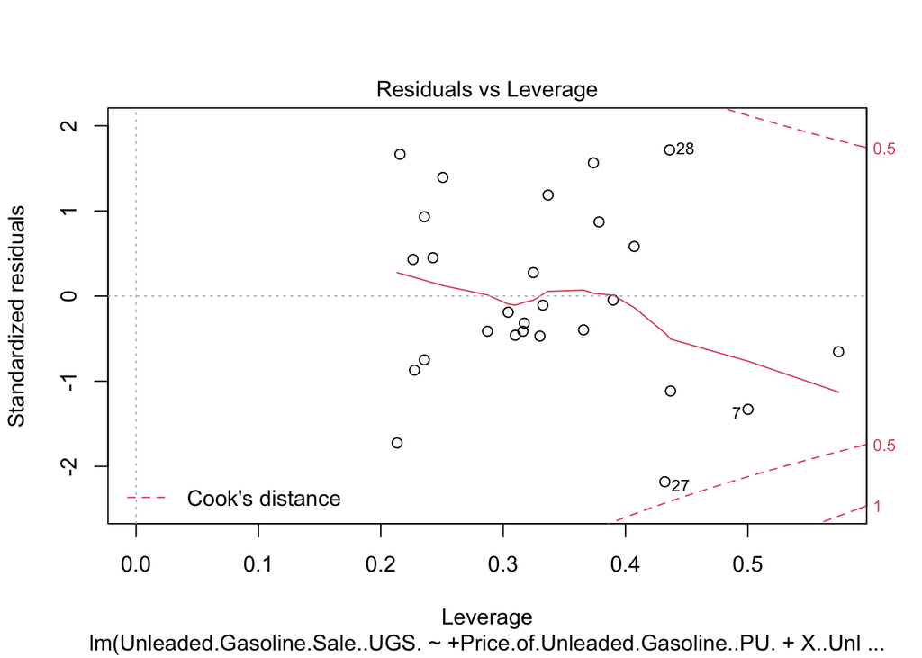

```r
plot(final_model12)
```